# Question

We began by defining the trigonometric ratios of **right triangles**. We saw it was beneficial to move to unit-**circle** definitions to allow for any angle (not just acute angles of right triangles). Now, we will see that when we plot trigonometric functions, we get **[waves](https://en.wikipedia.org/wiki/Sine_and_cosine#Graph_of_a_function_and_its_elementary_properties)** (and other [periodic](https://en.wikipedia.org/wiki/Periodic_function) functions).

In [Desmos](https://www.desmos.com/calculator), you can store a list of angles (in radians) with the following expression: `T=[0.395, 2.096, 2.338, 2.846, 3.512, 3.739, 4.112, 4.513, 5.55, 5.737]`

$$T=[0.395, 2.096, 2.338, 2.846, 3.512,
3.739, 4.112, 4.513, 5.55, 5.737]$$

From that list of angles, you can plot the corresponding points on the unit circle with the following expression: `(cos(T),sin(T))`. Find the corresponding graph.

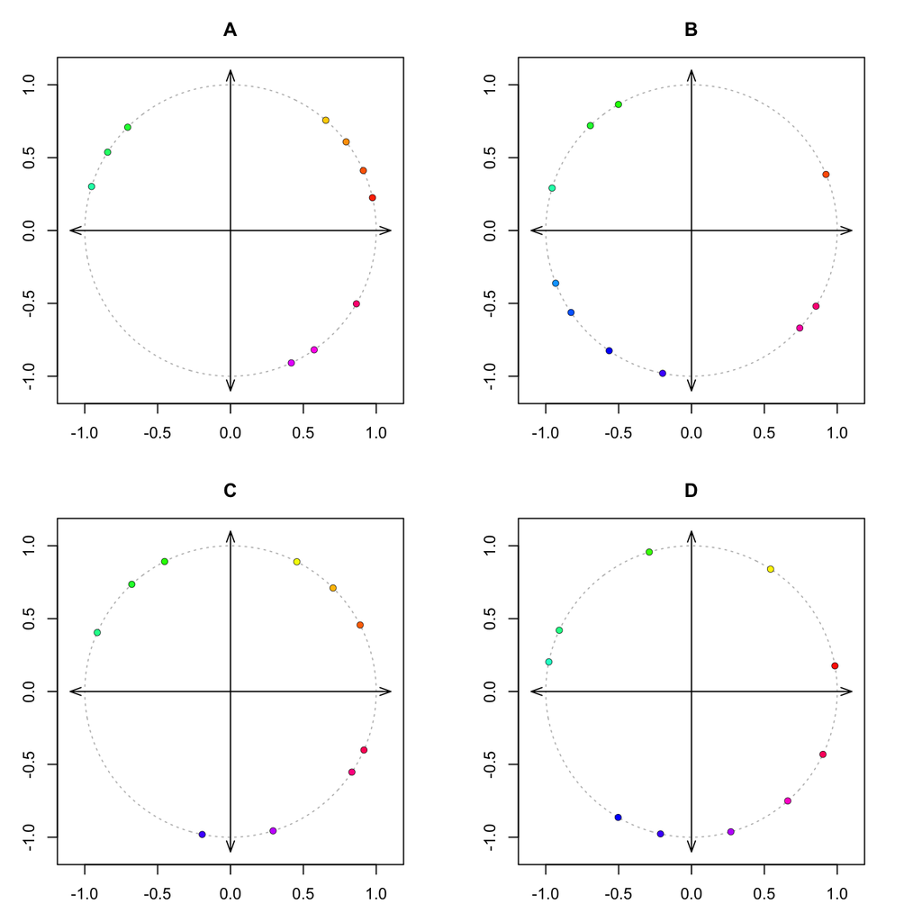

Now, in Desmos, you can type `(T,sin(T))` to get the points along the sine wave. Find the corresponding graph.

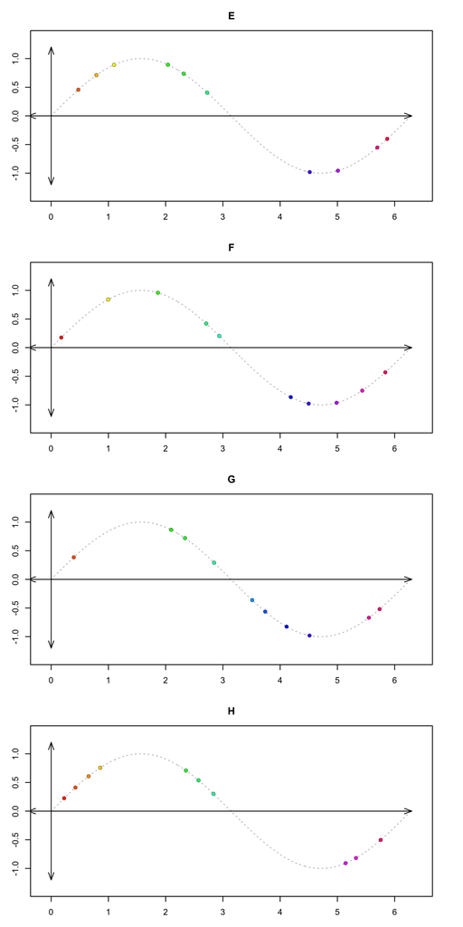

Lastly, in Desmos, you can type `(T,cos(T))` to get the points along the cosine wave. Find the corresponding graph.

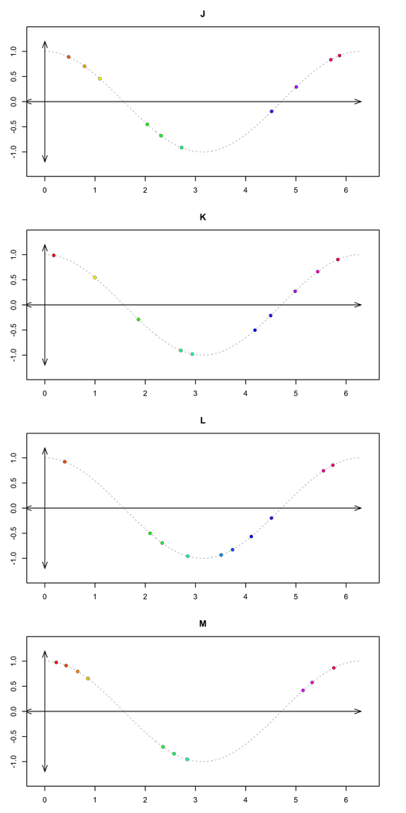

## Answerlist

- A
- B
- C
- D
- E
- F
- G
- H
- J
- K
- L
- M

# Solution

We are hoping to see how the unit-circle points correspond to the points on the waves. I think [this animation](https://en.wikipedia.org/wiki/Sine_and_cosine#/media/File:Circle_cos_sin.gif) does a great job of showing that the sine wave is created by plotting the $y$ coordinate (of the unit circle) as a function of time, and the cosine wave is created by plotting the $x$ coordinate as a function of time (and the angle grows linearly in time).

Here’s another attempt to show the connection between the unit circle and the sine wave:

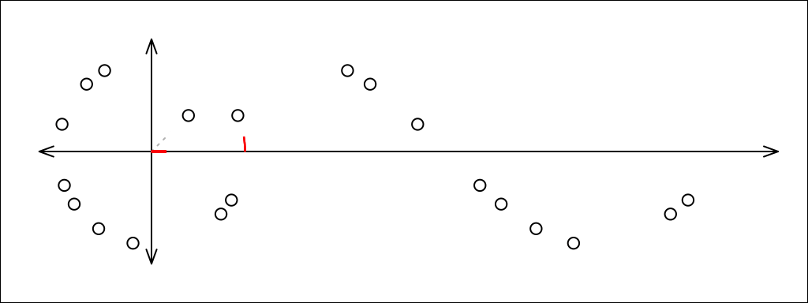

# Meta-information